# How Item Embeddings Are Trained

One training step by hand, then the general framework: gradient descent on watch data

Son Nguyen

## Where This Fits

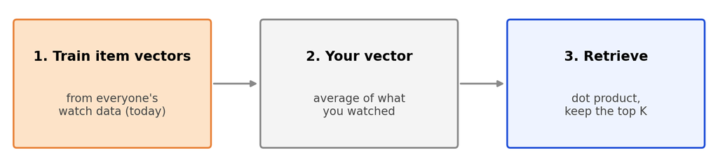

- In the RS lecture and practice problem, the item embeddings were **given** (“learned beforehand”).
- Today: **how they are learned**. First one step by hand, then the general recipe.

**Watched → pull the user and item vectors together. Skipped → push them apart.** Repeat millions of times.

# Practice Problem

## Setting Up the Learning Problem

**The dataset:** 6 users, one row each for Podcast X.

| Row | User | User vector $\mathbf{u}$ | Podcast | Label $r$ |
| --- | --- | --- | --- | --- |
| 1 | Ann | (1, 0) | X | 1 (listened) |
| 2 | Ben | (1, 0.2) | X | 1 (listened) |
| 3 | Cal | (1, 0.4) | X | 1 (listened) |
| 4 | Dee | (0, 0.6) | X | 0 (skipped) |
| 5 | Eli | (0.2, 1) | X | 0 (skipped) |
| 6 | Fay | (0, 1) | X | 0 (skipped) |

- **Input:** a (user, podcast) pair, e.g. (Ann, X).
- **Output variable:** the label $r$: 1 = listened, 0 = skipped.
- **Parameters:** Podcast X’s embedding $\mathbf{v}_X$ (2 numbers). The users’ vectors are given (already trained) and stay fixed here.
- **Prediction:** $\hat r = \mathbf{u}\cdot\mathbf{v}_X$.
- **Loss** over all 6 rows:

$$L(\mathbf{v}_X) = \tfrac{1}{2}\sum_{i=1}^{6} \left(r_i - \mathbf{u}_i\cdot\mathbf{v}_X\right)^2$$

The input has **no features**: just two IDs. The numbers describing Podcast X are **parameters**, learned from the labels.

## Practice Problem: Find Podcast X’s Embedding

Podcast X’s embedding starts **random**: $\mathbf{v}_X = (0.5, 0.5)$. Use **all 6 rows** and learning rate $\eta = 0.25$:

$$e_i = r_i - \mathbf{u}_i\cdot\mathbf{v}_X, \qquad \mathbf{v}_X \leftarrow \mathbf{v}_X + \eta \sum_{i=1}^{6} e_i\, \mathbf{u}_i$$

**(a)** Compute the prediction $\mathbf{u}_i\cdot\mathbf{v}_X$ and the error $e_i$ for every row.

**(b)** Take one gradient step: update $\mathbf{v}_X$.

**(c)** Compute the new predictions and the loss before and after. Did the loss go down?

**(d)** If we keep repeating the step, where does $\mathbf{v}_X$ go? Why there?

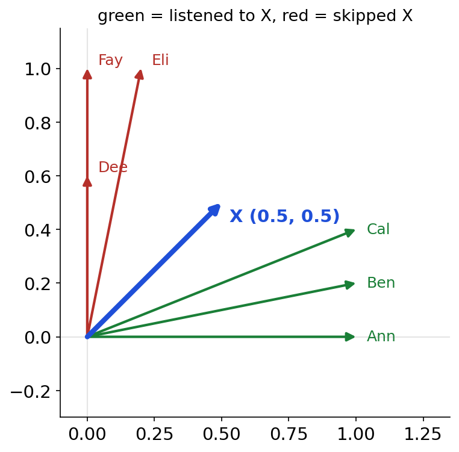

## Solution (a): Predict and Find the Error for Every Row

| User | $\mathbf{u}$ | Label $r$ | Prediction $\mathbf{u}\cdot\mathbf{v}_X$ | Error $e = r - \mathbf{u}\cdot\mathbf{v}_X$ |
| --- | --- | --- | --- | --- |
| Ann | (1, 0) | 1 | $1(0.5) + 0(0.5) = 0.5$ | $1 - 0.5 = 0.5$ |
| Ben | (1, 0.2) | 1 | $1(0.5) + 0.2(0.5) = 0.6$ | $1 - 0.6 = 0.4$ |
| Cal | (1, 0.4) | 1 | $1(0.5) + 0.4(0.5) = 0.7$ | $1 - 0.7 = 0.3$ |
| Dee | (0, 0.6) | 0 | $0(0.5) + 0.6(0.5) = 0.3$ | $0 - 0.3 = -0.3$ |
| Eli | (0.2, 1) | 0 | $0.2(0.5) + 1(0.5) = 0.6$ | $0 - 0.6 = -0.6$ |
| Fay | (0, 1) | 0 | $0(0.5) + 1(0.5) = 0.5$ | $0 - 0.5 = -0.5$ |

- **Listeners** (Ann, Ben, Cal): predicted too low, so the error is **positive**.

- **Skippers** (Dee, Eli, Fay): predicted too high, so the error is **negative**.

## Solution (b): One Gradient Step Using All 6 Users

| User | Error $e$ | $e \times \mathbf{u}$ |
| --- | --- | --- |
| Ann | 0.5 | $0.5 \times (1, 0) = (0.5, 0)$ |
| Ben | 0.4 | $0.4 \times (1, 0.2) = (0.4, 0.08)$ |
| Cal | 0.3 | $0.3 \times (1, 0.4) = (0.3, 0.12)$ |
| Dee | -0.3 | $-0.3 \times (0, 0.6) = (0, -0.18)$ |
| Eli | -0.6 | $-0.6 \times (0.2, 1) = (-0.12, -0.6)$ |
| Fay | -0.5 | $-0.5 \times (0, 1) = (0, -0.5)$ |
| **Sum** |  | $\mathbf{(1.08, -1.08)}$ |

$$\mathbf{v}_X \leftarrow (0.5, 0.5) + 0.25 \times (1.08, -1.08) = (0.5, 0.5) + (0.27, -0.27) = \mathbf{(0.77, 0.23)}$$

- Listeners (positive $e$) **pull** X toward their vectors; skippers (negative $e$) **push** it away.

- X moved toward Ann, Ben, Cal (right) and away from Dee, Eli, Fay (up).

## Solution (c): Did the Loss Go Down?

| User | Label $r$ | Before | After: $\mathbf{u}\cdot(0.77, 0.23)$ | New error |
| --- | --- | --- | --- | --- |
| Ann | 1 | 0.5 | $1(0.77) + 0(0.23) = 0.77$ | 0.23 |
| Ben | 1 | 0.6 | $1(0.77) + 0.2(0.23) = 0.816$ | 0.184 |
| Cal | 1 | 0.7 | $1(0.77) + 0.4(0.23) = 0.862$ | 0.138 |
| Dee | 0 | 0.3 | $0(0.77) + 0.6(0.23) = 0.138$ | -0.138 |
| Eli | 0 | 0.6 | $0.2(0.77) + 1(0.23) = 0.384$ | -0.384 |
| Fay | 0 | 0.5 | $0(0.77) + 1(0.23) = 0.23$ | -0.23 |

Every prediction moved **toward its label**: listeners up toward 1, skippers down toward 0.

$$L_{\text{before}} = \tfrac{1}{2}\left((0.5)^2 + (0.4)^2 + (0.3)^2 + (-0.3)^2 + (-0.6)^2 + (-0.5)^2\right) = 0.6$$
$$L_{\text{after}} = \tfrac{1}{2}\left((0.23)^2 + (0.184)^2 + (0.138)^2 + (-0.138)^2 + (-0.384)^2 + (-0.23)^2\right) = 0.163$$

The loss dropped from $0.6$ to $0.16$. ✓

## Watch X’s Embedding Move (Click to Step Through)

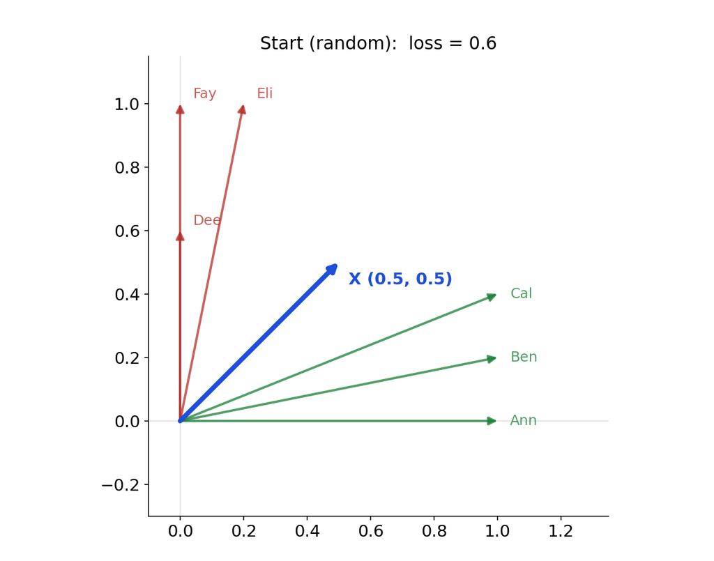

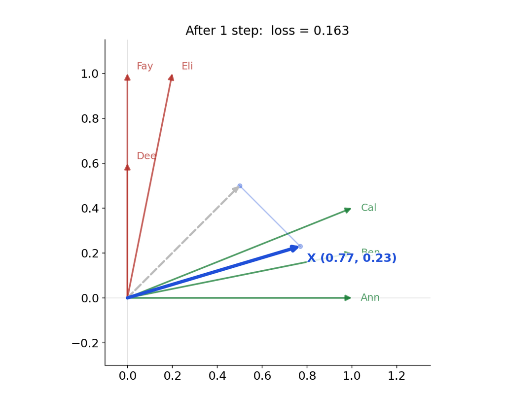

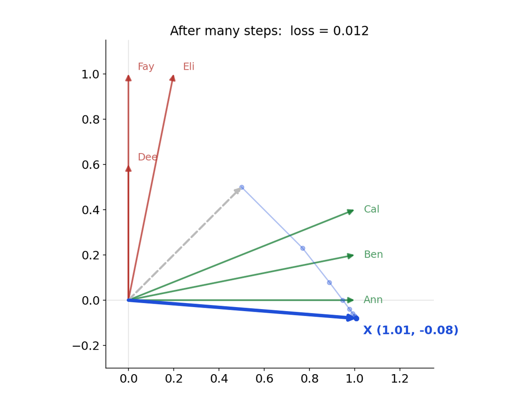

## Solution (d): Where Is X Heading?

| Step | 0 | 1 | 2 | 3 | 5 | 10 | 60 |
| --- | --- | --- | --- | --- | --- | --- | --- |
| $\mathbf{v}_X$ | (0.5, 0.5) | (0.77, 0.23) | (0.89, 0.08) | (0.95, 0) | (0.99, -0.06) | (1.01, -0.08) | (1.01, -0.08) |

- Repeating the step, $\mathbf{v}_X$ settles at about **(1.01, -0.08)**: **close to the listeners** (all near $(1, 0.2)$), **away from the skippers**.

- There, $\mathbf{u}\cdot\mathbf{v}_X \approx 1$ for listeners and $\approx 0$ for skippers: the predictions match the labels as well as possible.

- **With the users fixed, this is linear regression:** the user vectors are the features, $r$ is the response, and $\mathbf{v}_X$ holds the coefficients. Gradient descent reaches the least-squares answer.

- In full training, every podcast is found this way **and** every user’s vector is updated by the same rule (roles swapped).

A podcast’s embedding is pulled **toward the people who listened** and **away from those who skipped**. Podcasts with the same listeners end up close together.

# The General Framework

## The Learning Problem in General

**The dataset:** 6 listeners × 6 podcasts = 36 rows

| Row | User | Podcast | Label $r$ |
| --- | --- | --- | --- |
| 1 | Ann | N1 | 1 |
| 2 | Ann | N2 | 1 |
| 3 | Ann | N3 | 1 |
| 4 | Ann | C1 | 0 |
| 5 | Ann | C2 | 0 |
| 6 | Ann | C3 | 0 |
| 7 | Ben | N1 | 1 |
| 8 | Ben | N2 | 1 |
| 9 | Ben | N3 | 0 |
| … | … | … | … |
| 36 | Fay | C3 | 1 |

Each podcast appears in **6 rows** (once per listener); each listener in **6 rows**.

- **Dataset:** every (user, item, label) row from the logs. Here 36 rows; at YouTube, billions.
- **Input:** a (user, item) pair.
- **Output variable:** $r$ = 1 if the user watched or listened, 0 if not (sampled).
- **Parameters:** a vector $\mathbf{u}$ for every user and $\mathbf{v}$ for every item.
- **Prediction:** $\hat r = \mathbf{u}\cdot\mathbf{v}$.
- **Loss:** total squared error over all rows, plus a penalty:

$$L = \sum_{\text{rows}} \tfrac{1}{2}\,(r - \mathbf{u}\cdot\mathbf{v})^2 \;+\; \tfrac{\lambda}{2}\sum\left(\lVert\mathbf{u}\rVert^2 + \lVert\mathbf{v}\rVert^2\right)$$

- **Training:** gradient descent on $L$, one row at a time (SGD).

## From One Step to Training

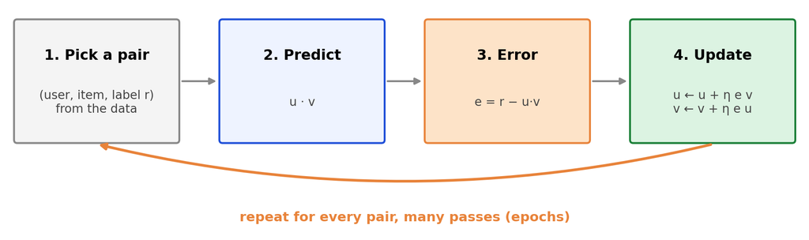

```
start every user vector and item vector at small random numbers
repeat for many passes (epochs):
    for each (user, item, r) in the data, in random order:
        e = r − u·v
        u ← u + η·e·v          (both updates use the old u and v)
        v ← v + η·e·u
store the item vectors → used for retrieval
```

## The Loss Behind the Rule

Training minimizes the squared error over all (user, item) pairs, plus a penalty that keeps vectors small:

$$L = \sum_{(\text{user},\,\text{item})} \tfrac{1}{2}\,(r - \mathbf{u}\cdot\mathbf{v})^2 \;+\; \tfrac{\lambda}{2}\left(\lVert\mathbf{u}\rVert^2 + \lVert\mathbf{v}\rVert^2\right)$$

For one pair, with $e = r - \mathbf{u}\cdot\mathbf{v}$:

$$\frac{\partial L}{\partial \mathbf{u}} = -e\,\mathbf{v} + \lambda\mathbf{u}, \qquad \frac{\partial L}{\partial \mathbf{v}} = -e\,\mathbf{u} + \lambda\mathbf{v}$$

Step against the gradient:

$$\mathbf{u} \leftarrow \mathbf{u} + \eta\,(e\,\mathbf{v} - \lambda\mathbf{u}), \qquad \mathbf{v} \leftarrow \mathbf{v} + \eta\,(e\,\mathbf{u} - \lambda\mathbf{v})$$

- This is **gradient descent**. One pair at a time = **stochastic gradient descent (SGD)**.
- The practice problem took one step using all 6 rows at once (**batch** gradient descent); SGD steps after each row. Both head to the same place. $\lambda$ is the same ridge penalty as in regression.
- The method is called **matrix factorization**: the watch table $\approx$ (user vectors) × (item vectors).

## Where the Labels Come From

Unlike a CNN, no person labels anything: **behavior is the label.**

| Label $r$ | From the logs |
| --- | --- |
| 1 = watched / listened | Ann played Podcast X |
| 1 = watched most of it | finished more than half (filters out clickbait) |
| 0 = not watched | **random** items the user did not play (“negative sampling”) |

A 0 is a guess: it may mean “never saw it”, not “did not want it”. Labels are free and plentiful, but noisy.

## Watch It Train: 6 Listeners, 6 Podcasts (Click to Step Through)

|  | N1 | N2 | N3 | C1 | C2 | C3 |
| --- | --- | --- | --- | --- | --- | --- |
| Ann | 1 | 1 | 1 | 0 | 0 | 0 |
| Ben | 1 | 1 | 0 | 0 | 0 | 0 |
| Cal | 0 | 1 | 1 | 0 | 0 | 1 |
| Dee | 0 | 0 | 0 | 1 | 1 | 1 |
| Eli | 0 | 0 | 0 | 1 | 1 | 0 |
| Fay | 1 | 0 | 0 | 0 | 1 | 1 |

1 = listened. N = news, C = comedy, but the model is **not told** this.

Each click = more training (SGD over all 36 cells).

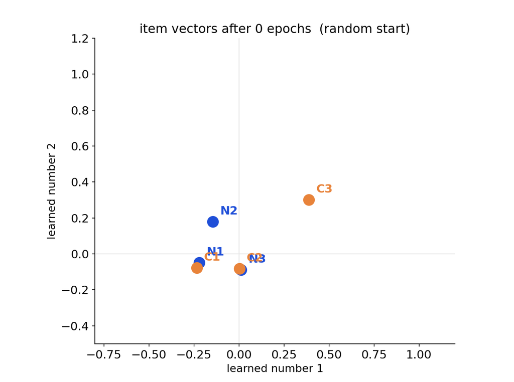

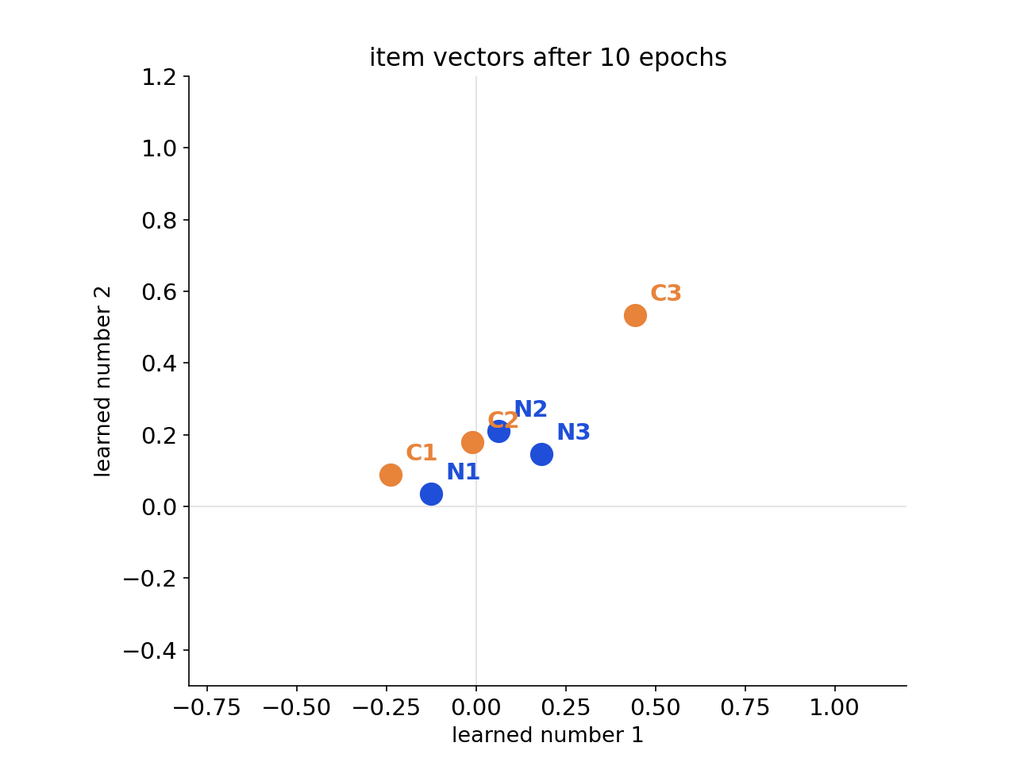

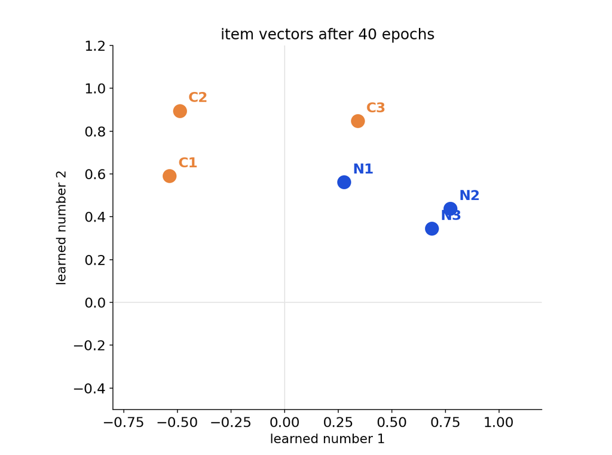

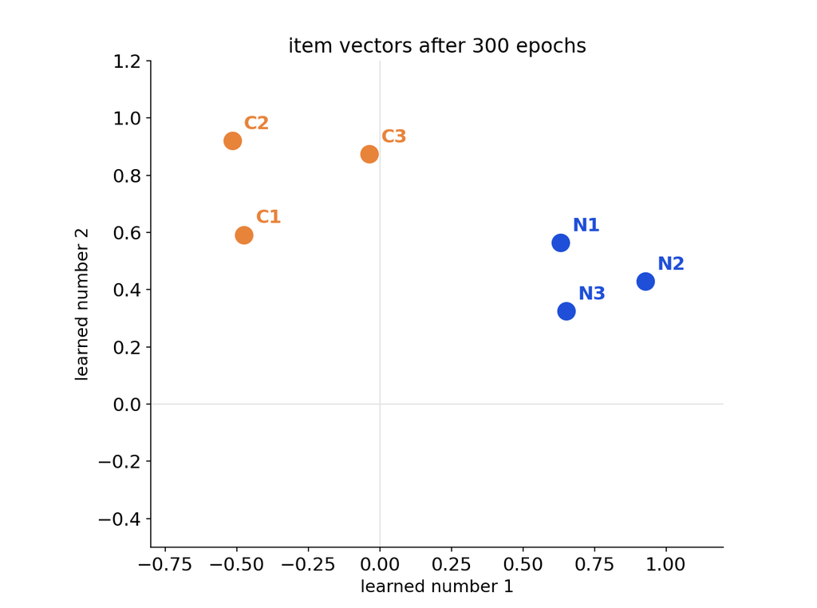

## What Training Achieved

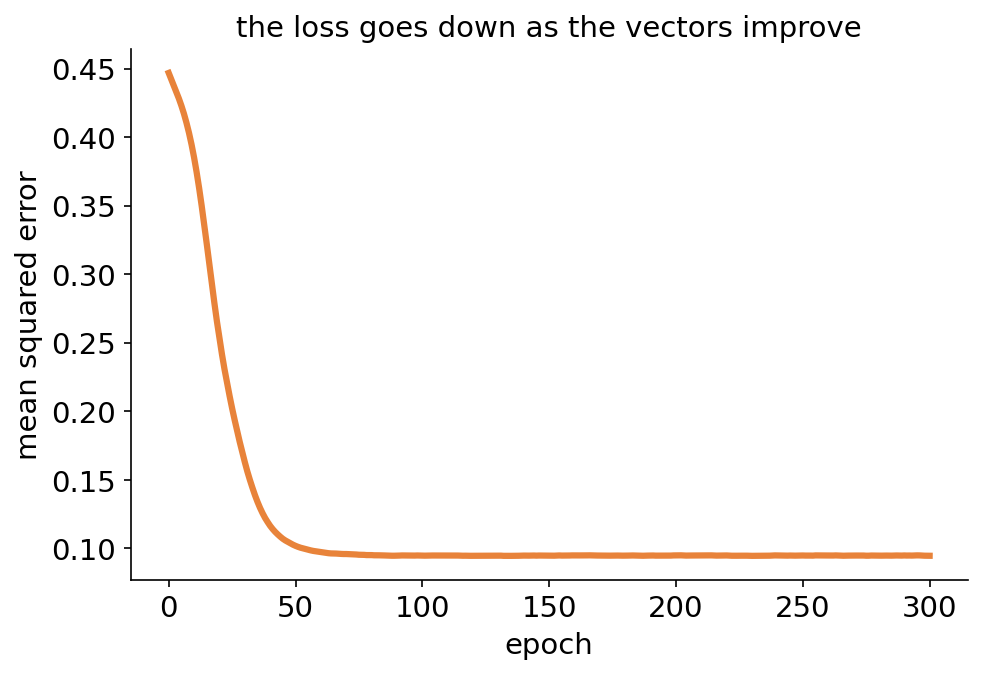

- Error: $0.45 \to 0.09$ after 300 epochs.

- News podcasts point one way, comedy another: average cosine **0.93** within a group vs **0.12** across groups.

- The two learned numbers have **no names**. We only see afterward that they separate news from comedy.

- These trained item vectors are what the RS lecture used for retrieval.

## Same Recipe as Training a Neural Network

|  | Neural network | Item embeddings |
| --- | --- | --- |
| Parameters | weights and biases | one vector per user and per item |
| Prediction | network output | $\mathbf{u}\cdot\mathbf{v}$ |
| Labels | given (e.g. image classes) | from behavior (watched = 1) |
| Loss | squared error / cross-entropy | squared error (or logistic) |
| Training | gradient descent | gradient descent (SGD) |

## Variations Used in Practice

| Method | Prediction | Idea |
| --- | --- | --- |
| **Matrix factorization** (today) | $\mathbf{u}\cdot\mathbf{v}$ | one free vector per user and item |
| **Logistic version** | $\sigma(\mathbf{u}\cdot\mathbf{v})$ = P(watch) | logistic regression loss, sampled 0s |
| **Two-tower network** | $f(\text{user features})\cdot g(\text{item features})$ | neural networks make the vectors, so new items get one immediately |
| **Item2vec** | items in the same session are “neighbors” | like word2vec for words |

All of them: **predict, measure the error, step down the gradient, repeat.**

## After Training

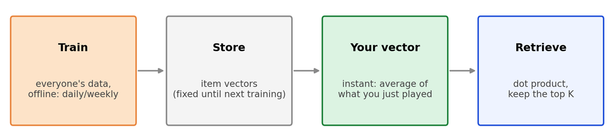

- **Slow loop:** item vectors are retrained on new data every day or week.
- **Fast loop:** a user’s vector updates instantly from their latest plays and feedback (the Sarah practice problem).

## Summary

| Step | In the practice problem |
| --- | --- |
| Data: one row per (user, podcast) with label $r$ | 6 users; Ann, Ben, Cal listened to X; Dee, Eli, Fay skipped |
| Start the embedding at random | $\mathbf{v}_X = (0.5, 0.5)$ |
| Predict $\mathbf{u}\cdot\mathbf{v}$, error $e = r - \mathbf{u}\cdot\mathbf{v}$ | errors 0.5, 0.4, 0.3, -0.3, -0.6, -0.5 |
| Gradient step: $\mathbf{v} \leftarrow \mathbf{v} + \eta\sum e\,\mathbf{u}$ | $\mathbf{v}_X = (0.77, 0.23)$; loss $0.6 \to 0.16$ |
| Repeat (all users and items, many passes) | $\mathbf{v}_X \to (1.01, -0.08)$, near its listeners |

Embeddings are **learned by gradient descent from behavior**: each item is pulled toward the people who used it and away from those who did not.